# if…else…

Daijiang Li

9/30/2021

# Control flow

Sometimes, we only want to execute some statements if certain conditions are met; sometimes, we want to execute some statement repetitively for each elements of a dataset or until certain conditions/values reached. This is where control-flow constructs come in. In this week’s lectures, we will largely focus on this topic.

For the syntax examples throughout this lecture, keep the following in mind:

- *statement* is a single R statement or a compound statement (a group of R statements enclosed in curly braces `{ }` and separated by semicolons).
- `cond` is an expression that resolves to `TRUE` or `FALSE`.
- `expr` is a statement that evaluates to a number or character string.
- `seq` is a sequence of numbers or character strings.

## Conditional execution

In conditional execution, a statement or statements are only executed if a specified condition is met. These constructs include `if-else`, `ifelse`, and `switch`.

Before we talk about these functions, it is necessary to talk about R’s logical operators.

| Operator | Description |
| --- | --- |
| `<` | less than |
| `<=` | less than or equal to |
| `>` | larger than |
| `>=` | larger than or equal to |
| `==` | exactly equal to |
| `!` | opposite of |
| `!=` | not equal to |
| `\|` | or |
| `&` | and |
| `%in%` | in |
| `isTRUE()` | is it true? |

[**Surprise surprise!**](https://stackoverflow.com/questions/9508518/why-are-these-numbers-not-equal)

```r
i = 0.1
i = i + 0.05
i == 0.15 # ? what do you say?
```

# `if ... else ...`

How does an if else statement work in R?

- Two steps: evaluation and execution (which are not necessarily repeated)
- Two outcomes in evaluation
  - Condition satisfied (i.e., outcome is TRUE) -> execute commands of “if”
  - Condition not satisfied (i.e., outcome is FALSE) -> execute commands of “else” (if any)
- if else statements can be nested

```r
# General form
if(cond){
  statement for TRUE
}

# else is optional
if(cond){
  statement for TRUE
} else {
  statement for FALSE
}
# bracket can be ignored too;
# but I find it is easy to read with it

if(cond){
  statement for TRUE
} else {
  another if ... else ...
}
```

```r
a <- 4
if (a %% 2 == 0) {
  b1 <- a * -1
}
a
```

```
## [1] 4
```

```r
b1
```

```
## [1] -4
```

```r
a <- 5
if (a %% 2 == 0) {
  b <- a * -1
} else {
  b <- a ^ 2
}
b
```

```
## [1] 25
```

```r
# nested if else
a <- 0.33
if (a %% 2 == 0) {
  b <- a * -1
} else {
  if (a %% 2 == 1) {
    b <- a ^ 2
  } else {
    b <- a * 10
  }
}
b
```

```
## [1] 3.3
```

Why use if else statement?

- Useful for situations with multiple scenarios
- Define your own categories
- Case-by-case manipulation of data

```r
# Define your own categories
small <- 1:5
medium <- 6:10
large <- 11:15

a <- 2
if (a %in% small) {
  b <- 'Small number'
} else if (a %in% medium) {
  b <- 'Medium Number'
} else if (a %in% large) {
  b <- 'Large number'
} else {
  b <- 'Number out of range'
}
b
```

```
## [1] "Small number"
```

```r
a <- 12
if (a %in% small) {
  b <- 'Small number'
} else {
  if (a %in% medium) {
    b <- 'Medium Number'
  } else {
    if (a %in% large) {
      b <- 'Large number'
    } else {
      b <- 'Number out of range'
    }
  }
}
b
```

```
## [1] "Large number"
```

#### Defensive coding

When write your own function or doing analysis, we should be very careful about potential errors / failures. It is recommended to warn / message / fail early!

```r
if(TRUE) warning("This is a warning")
```

```
## Warning: This is a warning
```

```r
if(TRUE) message("This is a message")
```

```
## This is a message
```

```r
# if(TRUE) stop("Stoped because of ...")
stopifnot()
```

So if else is useful to work with one value/situation/condition/evaluation at each time. What if we have multiple values/cases need to evaluate?

- `ifelse()`
- combine with loops such as `for()` (next lecture)

# `ifelse()`

`ifelse()` is a compact and vectorized version of the if-else construct. The syntax is:

```r
ifelse(cond, statement for TRUE, statement for FALSE)
```

### Problem to solve

Suppose that we have a vector `vec_a` with 5 elements:

```r
vec_a <- c(3, 2, -5, 7, 0)
```

Now we want to take square root for *positive and zero* values while leave negative values alone. How can we do this?

We may do the following things step by step for **each element**:

1. Is it non-negative?
2. If yes, take the square root (recall the functions from last class).
3. If no, return the original value.

#### Solution 1: combine if else with for()

We will talk more about loops in the next lecture.

```r
vec_a2 <- vector(mode = "numeric", length = length(vec_a)) # to hold results
for (i in 1:length(vec_a)){
  if (vec_a[i] >= 0){
    vec_a2[i] = sqrt(vec_a[i])
  } else {
    vec_a2[i] = vec_a[i]
  }
}
vec_a2
```

```
## [1]  1.732051  1.414214 -5.000000  2.645751  0.000000
```

| Pros | Cons |
| --- | --- |
| Intuitive | Multiple steps of coding: reate vector to hold results, then the 3-steps procedure for each element |
| Easy to follow | Relatively slow (imagine millions of elements) |

#### Solution 2: use `ifelse()`

```r
ifelse(vec_a >= 0, sqrt(vec_a), vec_a)
```

```
## [1]  1.732051  1.414214 -5.000000  2.645751  0.000000
```

```r
vec_a2
```

```
## [1]  1.732051  1.414214 -5.000000  2.645751  0.000000
```

#### Vectorization

A “whole project” thinking instead of “element-wise”.

- In `R`, this means a function takes the whole vector as input (instead of one element each time the `if()` function takes within the `for()` loop above)
- In `R`, vectorized functions are much faster
- But `for` loops are still very important (see next class)
- [More information about vectorization](http://www.noamross.net/blog/2014/4/16/vectorization-in-r--why.html)

**Why warning message??**

```r
Warning message:
In sqrt(vec_a) : NaNs produced
```

```r
(vec_test <- vec_a >= 0)
```

```
## [1]  TRUE  TRUE FALSE  TRUE  TRUE
```

```r
(vec_yes <- sqrt(vec_a)) # warning here
```

```
## [1] 1.732051 1.414214      NaN 2.645751 0.000000
```

```r
(vec_no <- vec_a)
```

```
## [1]  3  2 -5  7  0
```

```r
ifelse(vec_test, vec_yes, vec_no) # no warning
```

```
## [1]  1.732051  1.414214 -5.000000  2.645751  0.000000
```

- if the *i*th element of `vec_test` is `TRUE`
- then take the *i*th element of `vec_yes`
- otherwise, take the *i*th element of `vec_no`

Now, suppose instead of return the original value if it is negative, we want to return `NA`.

```r
ifelse(vec_a >= 0, sqrt(vec_a), NA)
```

```
## [1] 1.732051 1.414214       NA 2.645751 0.000000
```

```r
sqrt(ifelse(vec_a >= 0, vec_a, NA)) # No warning any more
```

```
## [1] 1.732051 1.414214       NA 2.645751 0.000000
```

#### `ifelse()` works for whole matrix too

```r
mat_a <- matrix(data = c(1:6, -2, -5, 0), nrow = 3, ncol = 3)
mat_a
```

```
##      [,1] [,2] [,3]
## [1,]    1    4   -2
## [2,]    2    5   -5
## [3,]    3    6    0
```

```r
ifelse(mat_a > 0, sqrt(mat_a), mat_a)
```

```
##          [,1]     [,2] [,3]
## [1,] 1.000000 2.000000   -2
## [2,] 1.414214 2.236068   -5
## [3,] 1.732051 2.449490    0
```

#### More examples

Suppose we have exam scores for students, and we want to assign pass (>= 60) or fail (<60) to each of them.

```r
set.seed(123)
scores <- data.frame(names = letters,
                     score = runif(n = 26, min = 30, max = 100))
head(scores, n = 3)
```

```
##   names    score
## 1     a 50.13043
## 2     b 85.18136
## 3     c 58.62838
```

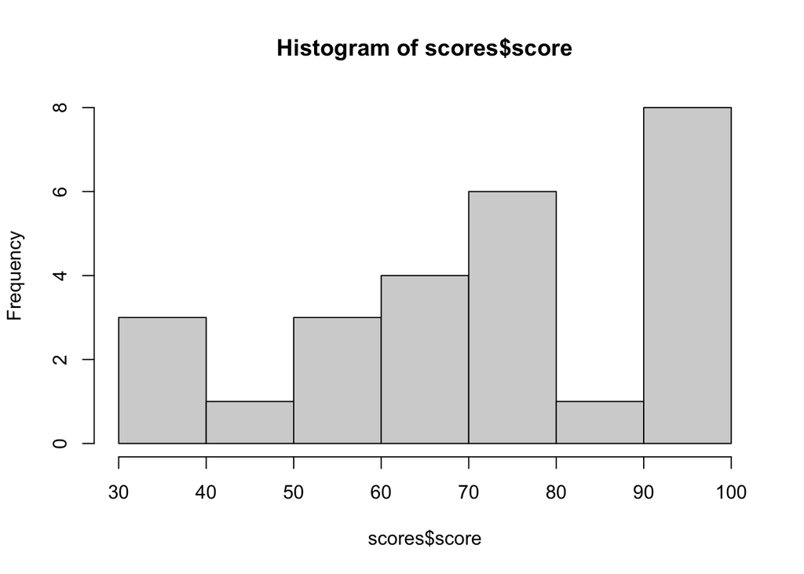

```r
hist(scores$score)
```

How do we add another column that will indicate pass and fail?

```r
str(scores)
```

```
## 'data.frame':    26 obs. of  2 variables:
##  $ names: chr  "a" "b" "c" "d" ...
##  $ score: num  50.1 85.2 58.6 91.8 95.8 ...
```

```r
scores$score
```

```
##  [1] 50.13043 85.18136 58.62838 91.81122 95.83271 33.18895 66.96738 92.46933
##  [9] 68.60045 61.96303 96.97833 61.73339 77.42994 70.08434 37.20473 92.98775
## [17] 47.22614 32.94417 52.95445 96.81526 92.26775 78.49624 74.83548 99.59888
## [25] 75.89941 79.59713
```

```r
(pass_fail <- ifelse(scores$score >= 60, "pass", "fail")) # recycle
```

```
##  [1] "fail" "pass" "fail" "pass" "pass" "fail" "pass" "pass" "pass" "pass"
## [11] "pass" "pass" "pass" "pass" "fail" "pass" "fail" "fail" "fail" "pass"
## [21] "pass" "pass" "pass" "pass" "pass" "pass"
```

```r
scores$status <- pass_fail
head(scores, n = 6)
```

```
##   names    score status
## 1     a 50.13043   fail
## 2     b 85.18136   pass
## 3     c 58.62838   fail
## 4     d 91.81122   pass
## 5     e 95.83271   pass
## 6     f 33.18895   fail
```

```r
table(scores$status)
```

```
##
## fail pass
##    7   19
```

```r
table(scores$score >= 60)
```

```
##
## FALSE  TRUE
##     7    19
```

What about if we want also assign “A” (>= 85), “B” (>= 75), “C” (>= 60) to those who passed the exam?

```r
# nested ifelse
vec_levels <-
  ifelse(scores$score < 60, "fail",
       ifelse(scores$score < 75, "C",
              ifelse(scores$score < 85, "B", "A")))
vec_score <- scores$score # to make it easier to check
names(vec_score) <- vec_levels # in pratice, you should make it as a new column
vec_score
```

```
##     fail        A     fail        A        A     fail        C        A
## 50.13043 85.18136 58.62838 91.81122 95.83271 33.18895 66.96738 92.46933
##        C        C        A        C        B        C     fail        A
## 68.60045 61.96303 96.97833 61.73339 77.42994 70.08434 37.20473 92.98775
##     fail     fail     fail        A        A        B        C        A
## 47.22614 32.94417 52.95445 96.81526 92.26775 78.49624 74.83548 99.59888
##        B        B
## 75.89941 79.59713
```

```r
dplyr::case_when(
  scores$score < 60 ~ "fail",
  scores$score < 75 ~ "C",
  scores$score < 85 ~ "B",
  TRUE ~ "A"
)
```

```
##  [1] "fail" "A"    "fail" "A"    "A"    "fail" "C"    "A"    "C"    "C"
## [11] "A"    "C"    "B"    "C"    "fail" "A"    "fail" "fail" "fail" "A"
## [21] "A"    "B"    "C"    "A"    "B"    "B"
```

If needed, you can also assign “D” (e.g. >= 50, < 60), “E” (< 50) to those who failed by replacing `"fail"` with another `ifelse()`.

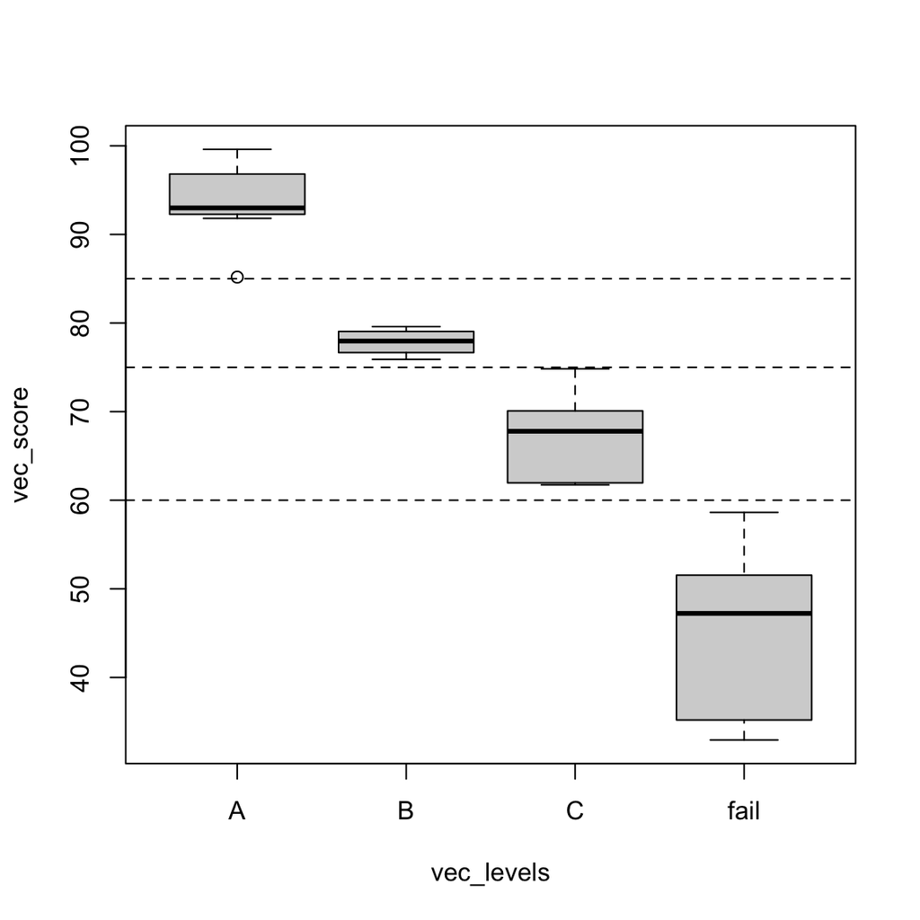

```r
# "A" (>= 85), "B" (>= 75), "C" (>= 60)
boxplot(vec_score ~ vec_levels)
abline(h = c(60, 75, 85), lty = 2)
```

**Be careful when use `ifelse()` with Dates and factors**

```r
(vec_x <- factor(c("b", "a", "d", "e")))
```

```
## [1] b a d e
## Levels: a b d e
```

```r
(vec_y <- ifelse(vec_x == "a", vec_x, NA))
```

```
## [1] NA  1 NA NA
```

```r
as.numeric(vec_x)
```

```
## [1] 2 1 3 4
```

```r
vec_x2 <- as.character(vec_x) # convert first
ifelse(vec_x2 == "a", vec_x2, NA)
```

```
## [1] NA  "a" NA  NA
```

See `?ifelse` for example of Dates

- The results of `ifelse()` have the same length as the input `test`, but attributes may not been preserved
- Values are selected from `vec_yes` and `vec_no`
- If `vec_yes` and `vec_no` are too short, they are recycled
- `NA` in the input give `NA` in the output

## `if else` vs `ifelse()`

`if(test) yes else no` is much more efficient and often much preferable to `ifelse(test, yes, no)` whenever `test` is a simple true/false result, i.e., when `length(test) == 1`.

# `switch()`

`switch` chooses statements based on the value of an expression. The syntax is `switch(expr, ...)` where `...` represents statements tied to the possible outcome values of `expr`. It’s easiest to understand how switch works by looking at the example in the following listing.

```r
feelings <- c("sad", "afraid")
for (i in feelings){
  print(
    switch(i,
           happy  = "I am glad you are happy",
           afraid = "There is nothing to fear",
           sad    = "Cheer up",
           angry  = "Calm down now"
    )
  )
}
```

```
## [1] "Cheer up"
## [1] "There is nothing to fear"
```

`switch` can be very useful when write our own functions to deal with different scenarios.

```r
mydate <- function(type="long") {
  switch(type,
         long =  format(Sys.time(), "%A %B %d %Y"),
         short = format(Sys.time(), "%m-%d-%y"),
         cat(type, "is not a recognized type\n")
  )
}
mydate("long")
```

```
## [1] "Thursday September 30 2021"
```

```r
mydate("short")
```

```
## [1] "09-30-21"
```

```r
mydate("medium")
```

```
## medium is not a recognized type
```